# Predictive Model of Weight Lifting Dataset

Sredan -JR

October 21, 2017

## Background

To be able to predict the weight lifting routine of twenty cases. The data was gathered from accelerometers. Using devices such as Jawbone Up,and Nike FuelBand, and Fitbit it is now possible to collect a large amount of data about personal activity relatively inexpensively. These types of devices are part of the quantified self movement a group of enthusiasts who take measurements about themselves regularly to improve their health,to find patterns in their behavior, or because they are tech geeks. One thing that people regularly do is quantify how much of a particular activity they do but they rarely quantify how well they do it. In this project, the goal is to use data from accelerometers on the belt, forearm, arm and dumbell of six participants. They were asked to perform barbell lifts correctly and incorrectly in five different ways.

## Loading required libraries and datasets

```r
setwd("C:/Users/jehuti1/Documents/2017_MachineLearning/projectml")
library(caret , quietly = TRUE )
library(randomForest , quietly = TRUE)
library(psych, quietly = TRUE)
```

```r
library(corrplot, quietly = TRUE)
traindsetq10 <- read.csv("pml-training.csv")
testdsetq10 <- read.csv("pml-testing.csv")
```

### Assessing the predictor columns NA count and removing extraneous columns

1. For examples timestamps, usernames and columns/features that are not populated significantly, less than 50%, with data.
2. Removed seven columns that do not contain accelerometer measurements.

```r
colcount = ncol(traindsetq10)
rowcount = nrow(traindsetq10)
na = integer()
for (i in 1:colcount) {
# Add the amount of na's  in the column
# If it is more than half of the total number of columns remove it

  fraction = sum(is.na(traindsetq10[,i])) / rowcount
           if (fraction > 0.5) {
             na = c(na,i)
           }
}

traindsetq10 = traindsetq10[,-c(na)]
foremovable <- grepl("kurtosis|skewness|X|yaw|user_name|new_window|timestamp",colnames(traindsetq10))
traindsetq10 <-  traindsetq10[,!foremovable]
traindsetq10shorten <- data.frame()
traindsetq10shorten <- traindsetq10
colnames(traindsetq10shorten)
```

```
##  [1] "num_window"           "roll_belt"            "pitch_belt"
##  [4] "total_accel_belt"     "gyros_belt_x"         "gyros_belt_y"
##  [7] "gyros_belt_z"         "accel_belt_x"         "accel_belt_y"
## [10] "accel_belt_z"         "magnet_belt_x"        "magnet_belt_y"
## [13] "magnet_belt_z"        "roll_arm"             "pitch_arm"
## [16] "total_accel_arm"      "gyros_arm_x"          "gyros_arm_y"
## [19] "gyros_arm_z"          "accel_arm_x"          "accel_arm_y"
## [22] "accel_arm_z"          "magnet_arm_x"         "magnet_arm_y"
## [25] "magnet_arm_z"         "roll_dumbbell"        "pitch_dumbbell"
## [28] "total_accel_dumbbell" "gyros_dumbbell_x"     "gyros_dumbbell_y"
## [31] "gyros_dumbbell_z"     "accel_dumbbell_x"     "accel_dumbbell_y"
## [34] "accel_dumbbell_z"     "magnet_dumbbell_x"    "magnet_dumbbell_y"
## [37] "magnet_dumbbell_z"    "roll_forearm"         "pitch_forearm"
## [40] "total_accel_forearm"  "gyros_forearm_x"      "gyros_forearm_y"
## [43] "gyros_forearm_z"      "accel_forearm_x"      "accel_forearm_y"
## [46] "accel_forearm_z"      "magnet_forearm_x"     "magnet_forearm_y"
## [49] "magnet_forearm_z"     "classe"
```

### Partition dataset to create a data set and validation set

```r
ptrain = createDataPartition(y = traindsetq10shorten$classe, p = 0.7,
                             list = FALSE)
usefortrain = traindsetq10shorten[ptrain,]
useforvalid = traindsetq10shorten[-ptrain,]
```

### Correlation Matrix

1. To explore the association between the predictors
2. To explore the possiblities of uncorrelated data
3. To confirm the use of principal component analysis

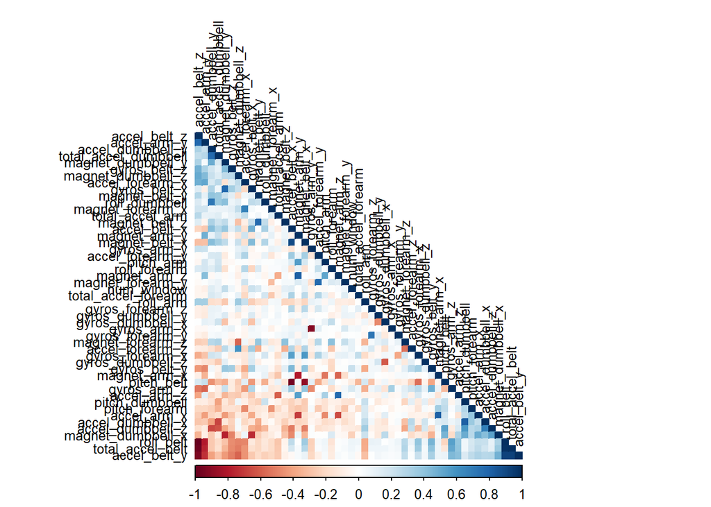

```r
corMatts <- cor(usefortrain[, -50])
corrplot(corMatts,order = "FPC", method = "color" , type = "lower", tl.cex = 0.8, tl.col = rgb(0,0,0))
```

### Scree Plots - Training Dataset Scree Plot

#### Used to determine how many components should be selected for the modeling stage

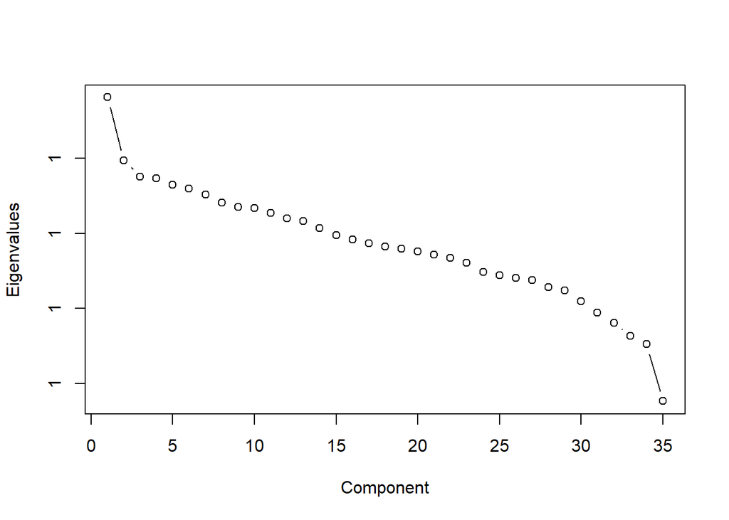

```r
# Correlation Plot

####### Training D Set Scree Plot
preProc351 <- preProcess(usefortrain[,-50], method = "pca", pcaComp = 35 )
trainpc <- predict(preProc351, usefortrain[, -50])
pca11 <- principal(trainpc, nfactors = 35, rotate = "none")
plot(pca11$values, type = "b", ylab = "Eigenvalues" , xlab = "Component"  )
```

### Validation Dataset Scree Plot

##### Used to determine how many components should be selected for the modeling stage

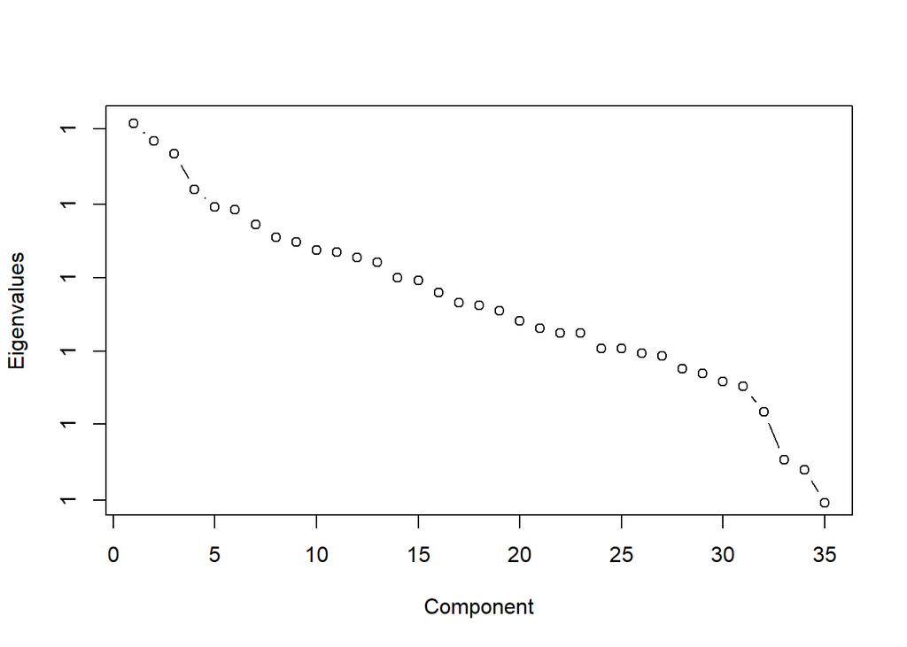

```r
####### Validation Set Scree Plot
preProc351val <- preProcess(useforvalid[,-50], method = "pca", pcaComp = 35 )
trainpcv <- predict(preProc351val, useforvalid[, -50])
pcaval <- principal(trainpcv, nfactors = 35, rotate = "none")
plot(pcaval$values, type = "b", ylab = "Eigenvalues" , xlab = "Component"  )
```

```r
#############################
############# TRAINING OF MODEL
```

### Predictive Model Train Control

```r
tcontrol <- trainControl(method = "cv" , number = 4)
```

### Constructing the Model Employing Random Forest

The random forest algorithm is used to build the model. Principal component analysis is used reduce the numbers of predictors by grouping the correlated predictors.

```r
fittingmdl <- train(classe ~ ., method = "rf",
                   preProcess = "pca", data = usefortrain, importance = TRUE)
```

### Applying Model To The Testing Dataset

#### Results - The twenty predictions based upon test dataset are not printed. Adhering to Honor Code.

1. Prediction error rate as meassured by out-of-bag error acceptable
2. Two variables were tried at each split, mtry = 2

```r
solution <- predict(fittingmdl,testdsetq10)
#print(solution)
# Final outcome not printed.
```

```r
print(fittingmdl)
```

```
## Random Forest
##
## 13737 samples
##    49 predictor
##     5 classes: 'A', 'B', 'C', 'D', 'E'
##
## Pre-processing: principal component signal extraction (49), centered
##  (49), scaled (49)
## Resampling: Bootstrapped (25 reps)
## Summary of sample sizes: 13737, 13737, 13737, 13737, 13737, 13737, ...
## Resampling results across tuning parameters:
##
##   mtry  Accuracy   Kappa
##    2    0.9650728  0.9558053
##   25    0.9496672  0.9363167
##   49    0.9498035  0.9364893
##
## Accuracy was used to select the optimal model using  the largest value.
## The final value used for the model was mtry = 2.
```

```r
print(fittingmdl$finalModel)
```

```
##
## Call:
##  randomForest(x = x, y = y, mtry = param$mtry, importance = TRUE)
##                Type of random forest: classification
##                      Number of trees: 500
## No. of variables tried at each split: 2
##
##         OOB estimate of  error rate: 2.23%
## Confusion matrix:
##      A    B    C    D    E class.error
## A 3880   11    9    5    1 0.006656426
## B   32 2580   42    4    0 0.029345372
## C    4   40 2334   16    2 0.025876461
## D    1    1   95 2149    6 0.045737123
## E    0    9   14   14 2488 0.014653465
```

### Confusion Matrix Generated for Train Dataset & Validation Data

1. Accuracy above 98% for Training dataset
2. Accuracy above 95% for Validation dataset
3. For both matrices, the p-values were less than 2.2e-16

### Confusion Matrix 1 - Obtained error estimates and accuracy

##### Training Dataset

```r
################TrainingDset Confusion ##Matrix#######################################################
 trainmatrix = predict(fittingmdl,traindsetq10shorten)
 matrix = confusionMatrix(traindsetq10shorten$classe,trainmatrix)
 print(matrix)
```

```
## Confusion Matrix and Statistics
##
##           Reference
## Prediction    A    B    C    D    E
##          A 5576    2    1    0    1
##          B   25 3752   17    1    2
##          C    0    9 3404    8    1
##          D    0    0   46 3165    5
##          E    0    2    2    4 3599
##
## Overall Statistics
##
##                Accuracy : 0.9936
##                  95% CI : (0.9924, 0.9946)
##     No Information Rate : 0.2854
##     P-Value [Acc > NIR] : < 2.2e-16
##
##                   Kappa : 0.9919
##  Mcnemar's Test P-Value : NA
##
## Statistics by Class:
##
##                      Class: A Class: B Class: C Class: D Class: E
## Sensitivity            0.9955   0.9965   0.9810   0.9959   0.9975
## Specificity            0.9997   0.9972   0.9989   0.9969   0.9995
## Pos Pred Value         0.9993   0.9881   0.9947   0.9841   0.9978
## Neg Pred Value         0.9982   0.9992   0.9959   0.9992   0.9994
## Prevalence             0.2854   0.1919   0.1768   0.1620   0.1839
## Detection Rate         0.2842   0.1912   0.1735   0.1613   0.1834
## Detection Prevalence   0.2844   0.1935   0.1744   0.1639   0.1838
## Balanced Accuracy      0.9976   0.9969   0.9899   0.9964   0.9985
```

### Confusion Matrix 2 - Obtained error estimates and accuracy

##### Validation Dataset

```r
################Validation Dset Confusion ###Matrix#######################################################
 validrandomf <- predict(fittingmdl,useforvalid[,-50])
 mattrixconva <- confusionMatrix(useforvalid$classe ,validrandomf )
 print(mattrixconva)
```

```
## Confusion Matrix and Statistics
##
##           Reference
## Prediction    A    B    C    D    E
##          A 1670    2    1    0    1
##          B   25 1095   16    1    2
##          C    0    9 1008    8    1
##          D    0    0   46  913    5
##          E    0    2    2    5 1073
##
## Overall Statistics
##
##                Accuracy : 0.9786
##                  95% CI : (0.9746, 0.9821)
##     No Information Rate : 0.288
##     P-Value [Acc > NIR] : < 2.2e-16
##
##                   Kappa : 0.9729
##  Mcnemar's Test P-Value : NA
##
## Statistics by Class:
##
##                      Class: A Class: B Class: C Class: D Class: E
## Sensitivity            0.9853   0.9883   0.9394   0.9849   0.9917
## Specificity            0.9990   0.9908   0.9963   0.9897   0.9981
## Pos Pred Value         0.9976   0.9614   0.9825   0.9471   0.9917
## Neg Pred Value         0.9941   0.9973   0.9866   0.9972   0.9981
## Prevalence             0.2880   0.1883   0.1823   0.1575   0.1839
## Detection Rate         0.2838   0.1861   0.1713   0.1551   0.1823
## Detection Prevalence   0.2845   0.1935   0.1743   0.1638   0.1839
## Balanced Accuracy      0.9921   0.9895   0.9678   0.9873   0.9949
```

### Principal Component of UnCorrelated Data

##### Y-axis sorts components in decreasing order of importance

##### Listed first, at the max location of the y-axis, is the most important component

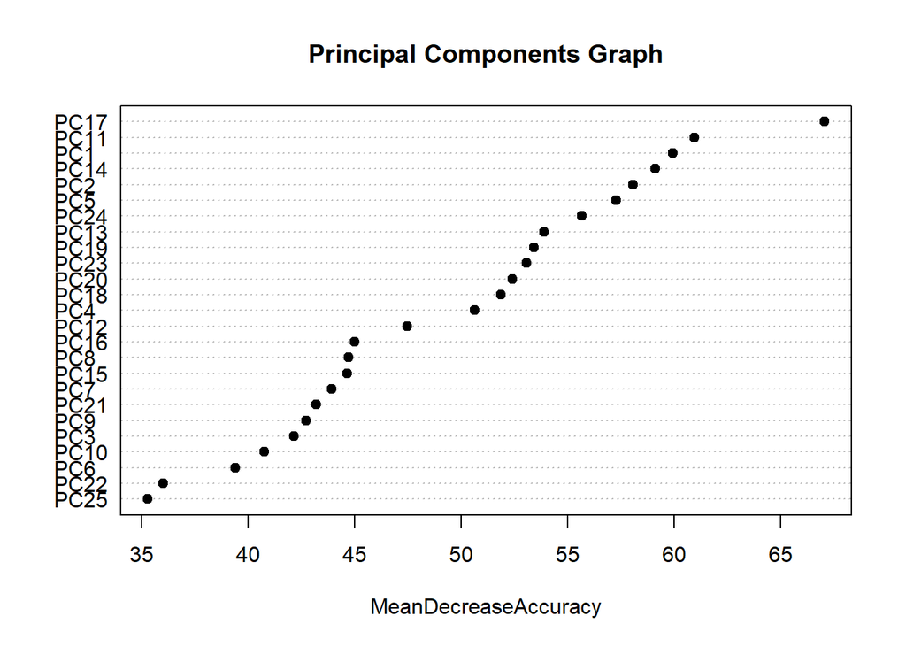

```r
varImpPlot(fittingmdl$finalModel, sort = TRUE, type = 1, pch = 19, col = 1, cex = 1,
           main = "Principal Components Graph")
```

```r
# Sys.time()
```

## References.

1. Mastering Machine Learning with R (2nd. Edition), C. Lesmeister. Packt(2017)
2. Data Mining For Business Intelligence, G. Shmueli, N.R. Patel, P.C. Bruce. John Wiley & Sons (2010)
3. Discovering Statistics Using R, A. Field, J. Miles, Z. Field. SAGE (2012)